# Classification

```python
import numpy as np
import pandas as pd
import matplotlib.pyplot as plt
from sklearn.cross_validation import KFold, train_test_split
from sklearn import preprocessing, neighbors, tree, naive_bayes, cross_validation
from sklearn.metrics import classification_report, confusion_matrix
import pylab as pyl
%matplotlib inline
```

## Read and Inspect Data

```python
data = pd.read_csv("data/food.csv", delimiter="\t")
```

```python
data.shape
```

```
(79470, 159)
```

```python
data.columns
```

```
Index([u'code', u'url', u'creator', u'created_t', u'created_datetime',
       u'last_modified_t', u'last_modified_datetime', u'product_name',
       u'generic_name', u'quantity',
       ...
       u'caffeine_100g', u'taurine_100g', u'ph_100g',
       u'fruits-vegetables-nuts_100g', u'collagen-meat-protein-ratio_100g',
       u'cocoa_100g', u'chlorophyl_100g', u'carbon-footprint_100g',
       u'nutrition-score-fr_100g', u'nutrition-score-uk_100g'],
      dtype='object', length=159)
```

```python
pd.options.display.max_columns = 200
```

```python
data.head()
```

|  | code | url | creator | created_t | created_datetime | last_modified_t | last_modified_datetime | product_name | generic_name | quantity | packaging | packaging_tags | brands | brands_tags | categories | categories_tags | categories_en | origins | origins_tags | manufacturing_places | manufacturing_places_tags | labels | labels_tags | labels_en | emb_codes | emb_codes_tags | first_packaging_code_geo | cities | cities_tags | … |
| --- | --- | --- | --- | --- | --- | --- | --- | --- | --- | --- | --- | --- | --- | --- | --- | --- | --- | --- | --- | --- | --- | --- | --- | --- | --- | --- | --- | --- | --- | --- |
| 0 | 0000000024600 | http://world-en.openfoodfacts.org/product/0000... | date-limite-app | 1434530704 | 2015-06-17T08:45:04Z | 1434535914 | 2015-06-17T10:11:54Z | Filet de bœuf | NaN | 2.46 kg | plastique | plastique | NaN | NaN | Filet de bœuf | fr:filet-de-boeuf | fr:Filet-de-boeuf | NaN | NaN | NaN | NaN | NaN | NaN | NaN | NaN | NaN | NaN | NaN | NaN | … |
| 1 | 0000000027205 | http://world-en.openfoodfacts.org/product/0000... | tacinte | 1458238630 | 2016-03-17T18:17:10Z | 1458238638 | 2016-03-17T18:17:18Z | NaN | NaN | NaN | NaN | NaN | NaN | NaN | NaN | NaN | NaN | NaN | NaN | NaN | NaN | NaN | NaN | NaN | NaN | NaN | NaN | NaN | NaN | … |
| 2 | 0000000036252 | http://world-en.openfoodfacts.org/product/0000... | tacinte | 1422221701 | 2015-01-25T21:35:01Z | 1422221855 | 2015-01-25T21:37:35Z | Lion Peanut x2 | NaN | NaN | NaN | NaN | NaN | NaN | NaN | NaN | NaN | NaN | NaN | NaN | NaN | NaN | NaN | NaN | NaN | NaN | NaN | NaN | NaN | … |
| 3 | 0000000039259 | http://world-en.openfoodfacts.org/product/0000... | tacinte | 1422221773 | 2015-01-25T21:36:13Z | 1422221926 | 2015-01-25T21:38:46Z | Twix x2 | NaN | NaN | NaN | NaN | NaN | NaN | NaN | NaN | NaN | NaN | NaN | NaN | NaN | NaN | NaN | NaN | NaN | NaN | NaN | NaN | NaN | … |
| 4 | 0000000039529 | http://world-en.openfoodfacts.org/product/0000... | teolemon | 1420147051 | 2015-01-01T21:17:31Z | 1439141740 | 2015-08-09T17:35:40Z | Pack de 2 Twix | NaN | NaN | NaN | NaN | Twix | twix | NaN | NaN | NaN | NaN | NaN | NaN | NaN | NaN | NaN | NaN | NaN | NaN | NaN | NaN | NaN | … |

```python
pd.options.display.max_columns = 20
```

## Data Pre-Processing

### Trim Rows that have almost all null values

```python
nullRowData = data.isnull().sum(axis=1).sort_values()
```

```python
nullRowData
```

```
15042     67
14922     71
66501     72
55360     73
48028     73
53681     74
14983     74
66481     74
38499     75
34738     75
66926     75
14984     75
34739     76
14899     76
39994     76
```

[output cut: 47 more lines]

```python
nullRowDataIndexReset = nullRowData.reset_index(drop=True)
```

```python
nullRowDataIndexReset
```

```
0         67
1         71
2         72
3         73
4         73
5         74
6         74
7         74
8         75
9         75
10        75
11        75
12        76
13        76
14        76
```

[output cut: 47 more lines]

There are 159 columns in the data, so it is clear from the graph below that many rows contain almost all null values.

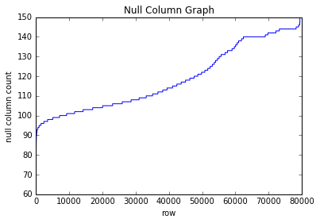

```python
plt.plot(nullRowDataIndexReset)
plt.ylabel('null column count')
plt.xlabel('row')
plt.title('Null Column Graph')
plt.show()
```

```python
nullsPerRow = data.isnull().sum(axis=1)
```

```python
nullsPerRow
```

```
0        133
1        144
2        140
3        140
4        139
5        120
6        123
7        135
8        119
9        119
10       141
11       107
12       107
13       140
14       109
```

[output cut: 47 more lines]

```python
dataMinusRows = data[nullsPerRow<120]
```

```python
dataMinusRows.shape
```

```
(47586, 159)
```

### Trim columns where almost all of the values are null

```python
nullColumnData = dataMinusRows.isnull().sum(axis=0)
```

```python
print nullColumnData.shape
print nullColumnData[:15]
```

```
(159,)
code                          0
url                           0
creator                       1
created_t                     1
created_datetime              1
last_modified_t               0
last_modified_datetime        0
product_name                161
generic_name              12991
quantity                    712
packaging                  1504
packaging_tags             1504
brands                      299
brands_tags                 299
categories                  829
dtype: int64
```

```python
nullColumnDataSorted = nullColumnData.sort_values()
print nullColumnDataSorted.shape
print nullColumnDataSorted
```

```
(159,)
code                                         0
url                                          0
last_modified_t                              0
last_modified_datetime                       0
states_tags                                  0
states                                       0
pnns_groups_2                                0
states_en                                    0
creator                                      1
created_t                                    1
created_datetime                             1
countries_tags                              25
countries_en                                25
countries                                   25
product_name                               161
brands                                     299
brands_tags                                299
quantity                                   712
image_url                                  788
image_small_url                            788
pnns_groups_1                              804
main_category                              829
main_category_en                           829
categories                                 829
categories_en                              829
categories_tags                            829
packaging                                 1504
packaging_tags                            1504
ingredients_from_palm_oil_n               1864
additives_n                               1864
                                         ...
nucleotides_100g                         47583
lauric-acid_100g                         47584
maltose_100g                             47584
myristic-acid_100g                       47585
arachidic-acid_100g                      47585
gamma-linolenic-acid_100g                47585
capric-acid_100g                         47585
caprylic-acid_100g                       47585
```

[output cut: 8 more lines]

```
caproic-acid_100g                        47586
behenic-acid_100g                        47586
lignoceric-acid_100g                     47586
cerotic-acid_100g                        47586
melissic-acid_100g                       47586
dihomo-gamma-linolenic-acid_100g         47586
elaidic-acid_100g                        47586
gondoic-acid_100g                        47586
mead-acid_100g                           47586
erucic-acid_100g                         47586
nervonic-acid_100g                       47586
ingredients_that_may_be_from_palm_oil    47586
no_nutriments                            47586
montanic-acid_100g                       47586
dtype: int64
```

There are 47586 rows in the data, so it is clear from the graph below that many columns contain almost all null values.

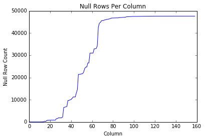

```python
plt.plot(nullColumnDataSorted.as_matrix())
plt.xlabel('Column')
plt.ylabel('Null Row Count')
plt.title('Null Rows Per Column')
plt.show()
```

```python
dataMinusRowsAndColumns = dataMinusRows.T[nullColumnData <35000].T
```

```python
dataMinusRowsAndColumns.shape
```

```
(47586, 66)
```

## Predict Countries that Food is sold in

We attempt to predict which country a food is sold in based on its nutriment makeup. We will use classification methods to do this.

First, look examine the countries field to get a sense for the data

```python
dataMinusRowsAndColumns.countries
```

```
8                       France
9               United Kingdom
11                 Royaume-Uni
12              United Kingdom
14                      France
15              United Kingdom
16                      España
17                      France
21                      France
25                     Germany
26                     Germany
33                      France
49       France,United Kingdom
51                      France
55                      France
```

[output cut: 47 more lines]

### Foods sold in multiple countries

```python
producedInMultipleCountries = np.sum(dataMinusRowsAndColumns.countries_en.str.contains(","))
producedInMultipleCountries
```

```
1351
```

```python
producedInCountriesCount = dataMinusRowsAndColumns.countries_en.str.count(",")
sortedProducedInCountriesCount = producedInCountriesCount.sort_values().reset_index(drop=True)
```

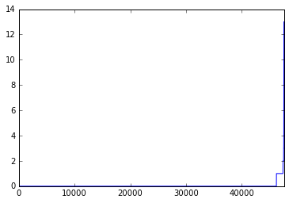

```python
sortedProducedInCountriesCount.plot()
```

Some foods are sold in multiple countries. You can see in the graph above, that this is true for a small percentage of the data. For simplicity, we will remove these rows from our analysis.

```python
#This is the percent of foods that are sold in multiple countries
float(producedInMultipleCountries) / dataMinusRowsAndColumns.shape[0]
```

[output not shown]

```python
producedInOneCountry = dataMinusRowsAndColumns.countries_en.str.contains(",") == False
print producedInOneCountry.shape
print producedInOneCountry.head()
```

```
(47586,)
8     True
9     True
11    True
12    True
14    True
Name: countries_en, dtype: bool
```

```python
singleCountryData = dataMinusRowsAndColumns[producedInOneCountry]
print singleCountryData.shape
```

```
(46210, 66)
```

```python
#We will only use the numberic collumns that have to do with nutriment values for this prediction
singleCountryData.columns[55:]
```

```
Index([u'energy_100g', u'fat_100g', u'saturated-fat_100g',
       u'carbohydrates_100g', u'sugars_100g', u'fiber_100g', u'proteins_100g',
       u'salt_100g', u'sodium_100g', u'nutrition-score-fr_100g',
       u'nutrition-score-uk_100g'],
      dtype='object')
```

```python
countriesRecords = singleCountryData.iloc[:,55:]
print countriesRecords.shape
```

```
(46210, 11)
```

```python
countriesTarget = singleCountryData.countries_en
print countriesTarget.shape
```

```
(46210,)
```

Now deal with the null values by using the mean

```python
numCols = countriesRecords.shape[1]
for i in range(numCols):
    currMean = countriesRecordsCopy.iloc[:,i].mean()
    countriesRecords.iloc[:,i].fillna(currMean, axis=0, inplace=True)
```

```python
countriesRecords.head()
```

|  | energy_100g | fat_100g | saturated-fat_100g | carbohydrates_100g | sugars_100g | fiber_100g | proteins_100g | salt_100g | sodium_100g | nutrition-score-fr_100g | nutrition-score-uk_100g |
| --- | --- | --- | --- | --- | --- | --- | --- | --- | --- | --- | --- |
| 8 | 1083.16219 | 13.147361 | 5.218562 | 27.647402 | 12.694918 | 2.82028 | 7.515199 | 1.100207 | 0.432134 | 8.044746 | 7.780121 |
| 9 | 1083.16219 | 13.147361 | 5.218562 | 27.647402 | 12.694918 | 2.82028 | 7.515199 | 1.100207 | 0.432134 | 8.044746 | 7.780121 |
| 11 | 1284.00000 | 7.000000 | 3.600000 | 54.200000 | 44.000000 | 4.70000 | 3.900000 | 0.200000 | 0.078740 | 10.000000 | 10.000000 |
| 12 | 1284.00000 | 7.000000 | 3.600000 | 54.200000 | 44.000000 | 4.70000 | 3.900000 | 0.199898 | 0.078700 | 10.000000 | 10.000000 |
| 14 | 177.00000 | 0.000000 | 0.000000 | 10.400000 | 10.400000 | 0.00000 | 0.000000 | 0.025400 | 0.010000 | 13.000000 | 2.000000 |

```python
#define a function for normalization
def normalizeMatrix(df):
    return (df - df.min()) / (df.max() - df.min())
```

```python
countriesRecords_norm = normalizeMatrix(countriesRecords)
```

```python
print countriesRecords_norm.shape
print countriesTarget.shape
```

```
(46210, 11)
(46210,)
```

```python
x_train, x_test, y_train, y_test = train_test_split(countriesRecords_norm, countriesTarget, test_size=0.2, random_state=33)
print x_train.shape
print y_train.shape
print x_test.shape
print y_test.shape
```

```
(36968, 11)
(36968,)
(9242, 11)
(9242,)
```

### Nearest Centroid Classifier

```python
def getPrototypeVectors(records, labels):
    classesDict = {}
    countDict = {}
    for i in labels.unique():
        classesDict[i] = np.zeros(records.shape[1])
        countDict[i] = 0
    for i in range(len(records)):
        currClass = labels.iloc[i]
        countDict[currClass] += 1
        classesDict[currClass] = classesDict[currClass] + records.iloc[i]
    for key,value in countDict.iteritems():
        classesDict[key] = classesDict[key] / value
    return classesDict
```

```python
#define a function to calculate the distance between two vectors using
#cosine similarity
def calcCosineSimilarity(x1, x2):
    x1Norm = np.linalg.norm(x1)
    x2Norm = np.linalg.norm(x2)
    sims = np.dot(x1,x2) / (x1Norm * x2Norm)
    return sims
```

```python
def testNearestCentroid(test_set, classesDict):
    classifications = []
    for i in range(len(test_set)):
        currTest = test_set.iloc[i]
        maxSimilarity = -2
        classPredicion = ''
        for key, value in classesDict.iteritems():
            cosSimilarity = calcCosineSimilarity(value, currTest)
            if (cosSimilarity > maxSimilarity):
                maxSimilarity = cosSimilarity
                classPrediction = key
        classifications.append(classPrediction)
    return classifications
```

```python
def calculateNearestCentroidCorrectness(classifications, real_labels):
    correctNumber = 0
    totalNumber = 0
    for i in range(len(classifications)):
        print ("predict: " + classifications[i])
        print ("real: " + real_labels.iloc[i])
        if classifications[i] == real_labels.iloc[i]:
            correctNumber += 1
        totalNumber += 1
    percentCorrect = float(correctNumber) / totalNumber
    return percentCorrect
```

```python
prototypeVectors = getPrototypeVectors(x_train, y_train)
```

```python
print prototypeVectors
```

```
{'Brazil': energy_100g                0.009180
fat_100g                   0.120532
saturated-fat_100g         0.056006
carbohydrates_100g         0.260546
sugars_100g                0.147677
fiber_100g                 0.044030
proteins_100g              0.075983
salt_100g                  0.018647
sodium_100g                0.018689
nutrition-score-fr_100g    0.460336
nutrition-score-uk_100g    0.475639
dtype: float64, 'Canada': energy_100g                0.006946
fat_100g                   0.099481
saturated-fat_100g         0.046570
carbohydrates_100g         0.172193
sugars_100g                0.151529
fiber_100g                 0.029313
proteins_100g              0.070222
salt_100g                  0.006737
sodium_100g                0.006747
nutrition-score-fr_100g    0.417159
nutrition-score-uk_100g    0.431490
dtype: float64, 'Qatar': energy_100g                0.005770
fat_100g                   0.230737
saturated-fat_100g         0.052186
carbohydrates_100g         0.088236
sugars_100g                0.125070
fiber_100g                 0.029750
proteins_100g              0.084391
salt_100g                  0.010282
sodium_100g                0.010289
nutrition-score-fr_100g    0.449893
nutrition-score-uk_100g    0.463407
dtype: float64, 'Italy': energy_100g                0.008507
fat_100g                   0.120276
saturated-fat_100g         0.059511
carbohydrates_100g         0.216024
sugars_100g                0.146018
fiber_100g                 0.030403
proteins_100g              0.081176
```

[output cut: 771 more lines]

```
sodium_100g                0.005894
nutrition-score-fr_100g    0.510661
nutrition-score-uk_100g    0.529576
dtype: float64, 'South Korea': energy_100g                0.011064
fat_100g                   0.133333
saturated-fat_100g         0.050333
carbohydrates_100g         0.321429
sugars_100g                0.052133
fiber_100g                 0.019833
proteins_100g              0.085271
salt_100g                  0.019307
sodium_100g                0.019365
nutrition-score-fr_100g    0.551020
nutrition-score-uk_100g    0.574468
dtype: float64}
```

```python
test_classifications = testNearestCentroid(x_test, prototypeVectors)
test_classifications[:5]
```

```
['Qatar', 'Slovenia', 'Aruba', 'Kenya', 'Slovakia']
```

```python
correct_test_percent = calculateNearestCentroidCorrectness(test_classifications, y_test)
```

[output not shown]

[output cut: 18429 more lines]

[output not shown]

```python
correct_test_percent
```

```
0.0006492101276779918
```

```python
train_classifications = testNearestCentroid(x_train, prototypeVectors)
train_classifications[:5]
```

```
['Norway', 'Kenya', 'India', 'Czech Republic', 'Venezuela']
```

```python
#Just scanning the list below, it's easy to see that the classifier is guessing countries incorrectly most times
#because it is guessing a country that is not France, and the right answer is usually France
correct_train_percent = calculateNearestCentroidCorrectness(test_classifications, y_train)
```

[output not shown]

[output cut: 18429 more lines]

[output not shown]

```python
correct_train_percent
```

```
0.0003246050638389959
```

```python
print y_test.value_counts().shape
print y_test.value_counts()
```

```
(59,)
France                       6828
Spain                         677
Germany                       511
United States                 281
United Kingdom                272
Switzerland                   156
Belgium                       119
Australia                      95
Portugal                       69
Italy                          47
Guadeloupe                     15
Austria                        13
Brazil                         13
Russia                         11
New Zealand                    10
Saint Pierre and Miquelon      10
Netherlands                     9
Tunisia                         9
Canada                          9
French Guiana                   8
Réunion                         7
Poland                          5
Mexico                          5
Sweden                          4
Senegal                         4
Cambodia                        3
New Caledonia                   3
Romania                         3
fr:Quebec                       3
Hong Kong                       2
Denmark                         2
Czech Republic                  2
French Polynesia                2
Bulgaria                        2
Luxembourg                      2
Cuba                            2
South Africa                    2
European Union                  2
Chile                           2
Argentina                       2
China                           2
Thailand                        2
Turkey                          1
Hungary                         1
Peru                            1
Côte d'Ivoire                   1
Algeria                         1
Norway                          1
Republique-de-chine             1
Burkina Faso                    1
Lebanon                         1
Finland                         1
Ireland                         1
Israel                          1
Martinique                      1
Philippines                     1
Indonesia                       1
Slovenia                        1
Greece                          1
Name: countries_en, dtype: int64
```

```python
#This is the percentage of the foods in the test set that were sold
#in France
print 6828.0 / y_test.shape[0]
```

```
0.738801125298
```

The data is very skewed, with the vast majority of foods belonging to one cateogry (France). Let's try the analysis without France included.

```python
notFrance = singleCountryData.countries_en != 'France'
```

```python
singleCountryDataMinusFrance = singleCountryData[notFrance]
```

```python
countriesRecords_noFrance = singleCountryDataMinusFrance.iloc[:,55:]
print countriesRecords_noFrance.shape
```

```
(11764, 11)
```

```python
countriesTarget_noFrance = singleCountryDataMinusFrance.countries_en
print countriesTarget_noFrance.shape
```

```
(11764,)
```

Now deal with the null values by using the mean

```python
numCols = countriesRecords_noFrance.shape[1]
for i in range(numCols):
    currMean = countriesRecordsCopy.iloc[:,i].mean()
    countriesRecords_noFrance.iloc[:,i].fillna(currMean, axis=0, inplace=True)
```

```python
countriesRecords_noFrance.head()
```

|  | energy_100g | fat_100g | saturated-fat_100g | carbohydrates_100g | sugars_100g | fiber_100g | proteins_100g | salt_100g | sodium_100g | nutrition-score-fr_100g | nutrition-score-uk_100g |
| --- | --- | --- | --- | --- | --- | --- | --- | --- | --- | --- | --- |
| 9 | 1083.16219 | 13.147361 | 5.218562 | 27.647402 | 12.694918 | 2.82028 | 7.515199 | 1.100207 | 0.432134 | 8.044746 | 7.780121 |
| 11 | 1284.00000 | 7.000000 | 3.600000 | 54.200000 | 44.000000 | 4.70000 | 3.900000 | 0.200000 | 0.078740 | 10.000000 | 10.000000 |
| 12 | 1284.00000 | 7.000000 | 3.600000 | 54.200000 | 44.000000 | 4.70000 | 3.900000 | 0.199898 | 0.078700 | 10.000000 | 10.000000 |
| 15 | 144.00000 | 0.900000 | 5.218562 | 2.900000 | 2.500000 | 1.80000 | 3.600000 | 0.000000 | 0.000000 | 8.044746 | 7.780121 |
| 16 | 320.00000 | 3.500000 | 5.218562 | 7.500000 | 12.694918 | 2.82028 | 3.600000 | 1.100207 | 0.432134 | 8.044746 | 7.780121 |

```python
countriesRecords_noFrance_norm = normalizeMatrix(countriesRecords_noFrance)
```

```python
x_train_noFrance, x_test_noFrance, y_train_noFrance, y_test_noFrance = train_test_split(countriesRecords_noFrance_norm, countriesTarget_noFrance, test_size=0.2, random_state=33)
print x_train.shape
print y_train.shape
print x_test.shape
print y_test.shape
```

```
(36968, 11)
(36968,)
(9242, 11)
(9242,)
```

```python
prototypeVectors_noFrance = getPrototypeVectors(x_train_noFrance, y_train_noFrance)
```

```python
test_classifications_noFrance = testNearestCentroid(x_test_noFrance, prototypeVectors_noFrance)
test_classifications_noFrance[:5]
```

```
['Slovenia',
 'Slovakia',
 'United Arab Emirates',
 'Burkina Faso',
 'South Africa']
```

```python
correct_test_percent_noFrance = calculateNearestCentroidCorrectness(test_classifications_noFrance, y_test_noFrance)
```

[output not shown]

[output cut: 4651 more lines]

[output not shown]

```python
correct_test_percent_noFrance
```

```
0.07904802379940501
```

```python
train_classifications_noFrance = testNearestCentroid(x_train_noFrance, prototypeVectors_noFrance)
train_classifications_noFrance[:5]
```

```
['Burkina Faso', 'Peru', 'Israel', 'Finland', 'Chile']
```

```python
correct_train_percent_noFrance = calculateNearestCentroidCorrectness(test_classifications_noFrance, y_train_noFrance)
```

[output not shown]

[output cut: 4651 more lines]

[output not shown]

```python
correct_train_percent_noFrance
```

```
0.034424139396515084
```

### KNN

```python
X_train, X_test, Y_train, Y_test = train_test_split(countriesRecords, countriesTarget, test_size=0.2, random_state=33)
```

```python
#normalize the data
min_max_scaler = preprocessing.MinMaxScaler().fit(X_train)
train_norm = min_max_scaler.transform(X_train)
test_norm = min_max_scaler.transform(X_test)
```

```python
def knnTester(xTrain, yTrain, xTest, yTest):
    results = pd.DataFrame()
    for n_neighbors in range(1, 25):
        distance_knnclf = neighbors.KNeighborsClassifier(n_neighbors, weights="distance")
        distance_knnclf.fit(xTrain, yTrain)
        distance_score = distance_knnclf.score(xTest, yTest)
        uniform_knnclf = neighbors.KNeighborsClassifier(n_neighbors, weights="uniform")
        uniform_knnclf.fit(xTrain, yTrain)
        uniform_score = uniform_knnclf.score(xTest, yTest)
        results = results.append([[n_neighbors, distance_score, uniform_score]])
    results.columns = ["Neighbors", "DistanceScore", "UniformScore"]
    return results
```

```python
res = knnTester(train_norm, Y_train, test_norm, Y_test)
```

```python
#print out the results
res
```

|  | Neighbors | DistanceScore | UniformScore |
| --- | --- | --- | --- |
| 0 | 1 | 0.698009 | 0.698009 |
| 0 | 2 | 0.701363 | 0.722246 |
| 0 | 3 | 0.734148 | 0.735447 |
| 0 | 4 | 0.745293 | 0.743887 |
| 0 | 5 | 0.753300 | 0.747457 |
| 0 | 6 | 0.756546 | 0.749513 |
| 0 | 7 | 0.759143 | 0.749188 |
| 0 | 8 | 0.760009 | 0.747998 |
| 0 | 9 | 0.758169 | 0.745077 |
| 0 | 10 | 0.758710 | 0.746051 |
| 0 | 11 | 0.760225 | 0.743995 |
| 0 | 12 | 0.761091 | 0.744752 |
| 0 | 13 | 0.760874 | 0.744860 |
| 0 | 14 | 0.759792 | 0.743670 |
| 0 | 15 | 0.760766 | 0.746592 |
| 0 | 16 | 0.760550 | 0.745293 |
| 0 | 17 | 0.761523 | 0.744644 |
| 0 | 18 | 0.762173 | 0.745510 |
| 0 | 19 | 0.762930 | 0.744536 |
| 0 | 20 | 0.763255 | 0.745726 |
| 0 | 21 | 0.763038 | 0.745185 |
| 0 | 22 | 0.762822 | 0.744428 |
| 0 | 23 | 0.762389 | 0.743670 |
| 0 | 24 | 0.762389 | 0.743670 |

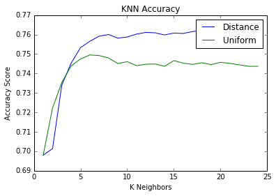

```python
pyl.plot(res["Neighbors"], res["DistanceScore"], label="Distance Score")
pyl.plot(res["Neighbors"], res["UniformScore"], label="Uniform Score")
pyl.legend(('Distance', 'Uniform'))
pyl.ylabel('Accuracy Score')
pyl.xlabel('K Neighbors')
pyl.title("KNN Accuracy")
pyl.show()
```

The best accuracy for KNN is obtained using the distance weighting and a K value of 20. We will re-do the analysis using those values.

```python
n_neighbors = 20
knnclf = neighbors.KNeighborsClassifier(n_neighbors, weights='distance')
knnclf.fit(train_norm, Y_train)
```

```
KNeighborsClassifier(algorithm='auto', leaf_size=30, metric='minkowski',
           metric_params=None, n_jobs=1, n_neighbors=20, p=2,
           weights='distance')
```

```python
knnpreds_test = knnclf.predict(test_norm)
knnpreds_test
```

```
array(['France', 'France', 'France', ..., 'France', 'France', 'France'], dtype=object)
```

```python
#calculate the average accuracy score for the test data
print knnclf.score(test_norm, Y_test)
```

```
0.763254706773
```

```python
#calculate the average accuracy score for the training data
print knnclf.score(train_norm, Y_train)
```

```
0.961777753733
```

```python
#Generate the confusion matrix
knncm = (confusion_matrix(Y_test, knnpreds_test))
print knncm
```

```
[[ 0  0  0 ...,  0  0  0]
 [ 0  0  0 ...,  0  0  0]
 [ 0  0  3 ...,  0  0  0]
 ...,
 [ 0  0  0 ..., 48  0  0]
 [ 0  0  0 ...,  1 47  0]
 [ 0  0  0 ...,  0  0  0]]
```

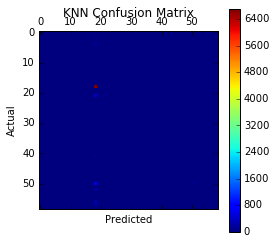

```python
#visualize the confusion matrix
%matplotlib inline
pyl.matshow(knncm)
pyl.title('KNN Confusion Matrix')
pyl.colorbar()
pyl.ylabel('Actual')
pyl.xlabel('Predicted')
pyl.show()
```

```python
#print the classification report
print(classification_report(Y_test, knnpreds_test))
```

```
             precision    recall  f1-score   support

    Algeria       0.00      0.00      0.00         1
  Argentina       0.00      0.00      0.00         2
  Australia       1.00      0.03      0.06        95
    Austria       1.00      0.08      0.14        13
    Belgium       0.09      0.01      0.02       119
     Brazil       0.50      0.08      0.13        13
   Bulgaria       0.00      0.00      0.00         2
Burkina Faso       0.00      0.00      0.00         1
   Cambodia       0.00      0.00      0.00         3
     Canada       0.00      0.00      0.00         9
      Chile       0.00      0.00      0.00         2
      China       0.00      0.00      0.00         2
       Cuba       0.00      0.00      0.00         2
Czech Republic       0.00      0.00      0.00         2
Côte d'Ivoire       0.00      0.00      0.00         1
    Denmark       0.00      0.00      0.00         2
European Union       0.00      0.00      0.00         2
    Finland       0.00      0.00      0.00         1
     France       0.77      0.98      0.86      6828
French Guiana       0.00      0.00      0.00         8
French Polynesia       0.00      0.00      0.00         2
    Germany       0.66      0.24      0.36       511
     Greece       0.00      0.00      0.00         1
 Guadeloupe       1.00      0.07      0.12        15
  Hong Kong       0.00      0.00      0.00         2
    Hungary       0.00      0.00      0.00         1
  Indonesia       0.00      0.00      0.00         1
    Ireland       0.00      0.00      0.00         1
     Israel       0.00      0.00      0.00         1
      Italy       0.60      0.06      0.12        47
    Lebanon       0.00      0.00      0.00         1
 Luxembourg       0.00      0.00      0.00         2
 Martinique       0.00      0.00      0.00         1
     Mexico       0.00      0.00      0.00         5
Netherlands       0.00      0.00      0.00         9
New Caledonia       0.00      0.00      0.00         3
New Zealand       1.00      0.10      0.18        10
     Norway       0.00      0.00      0.00         1
```

[output cut: 8 more lines]

```
Saint Pierre and Miquelon       0.00      0.00      0.00        10
    Senegal       1.00      0.25      0.40         4
   Slovenia       0.00      0.00      0.00         1
South Africa       0.00      0.00      0.00         2
      Spain       0.71      0.13      0.22       677
     Sweden       0.00      0.00      0.00         4
Switzerland       0.73      0.05      0.10       156
   Thailand       0.00      0.00      0.00         2
    Tunisia       0.00      0.00      0.00         9
     Turkey       0.00      0.00      0.00         1
United Kingdom       0.72      0.18      0.28       272
United States       0.77      0.17      0.27       281
  fr:Quebec       0.00      0.00      0.00         3

avg / total       0.74      0.76      0.70      9242
```